# Project - Modelling to predict dementia, a neurodegenerative disorder

DA5030

Prachi Sardana

12-05-2023, Fall 2023

# Detection of dementia

Resource - About the Dataset - **https://www.kaggle.com/datasets/shashwatwork/dementia-prediction-dataset**

# Introduction

Dementia is a neuro degenerative disorder that results in cognitive decline ultimately leading to memory problems, thinking and behaviour impacting the overall person’s ability to do every day activities. Apart from the memory impairement, it results in disruption in thought patterns, including emotional problems, difficulties with language and decreased motivation. Dementia ultimately has a significant effect on the individual, caregivers, and on social relationships in general.A diagnosis of dementia requires the observation of a change from a person’s usual mental functioning and a greater cognitive decline than what is caused by normal aging.Dementia results from a variety of diseases and injuries that primarily or secondarily affect the brain, such as Alzheimer’s disease or stroke.Dementia is one of the major causes of disability and dependency among older people worldwide. It can be overwhelming, not only for the people who have it, but also for their carers and families. There is often a lack of awareness and understanding of dementia, resulting in stigmatization and barriers to diagnosis and care. The impact of dementia on carers, family, and society at large can be physical, psychological, social and economic.

# Goal of the Project

The goal of the project is to perform machine learning algorithms and predict the best modelling approach to predict the target group dementia, non dementia and converted among the subjects ( which are patients). The non demented are the patients which had no dementia , demented cases are those where subject id’s had dementia and converted are those subject id’s which became demented or non demented after the last vist. THe main aim of the project is to perform multi class classification and use non parametric methods like Naive Bayes, Random Forest and Support vector machines to predict demented, non demented and converted cases.

# Understanding the data

## Summary- This set consists of a longitudinal collection of 150 subjects aged 60 to 96. Each subject was scanned on two or more visits, separated by at least one year for a total of 373 imaging sessions. For each subject, 3 or 4 individual T1-weighted MRI scans obtained in single scan sessions are included. The subjects are all right-handed and include both men and women. 72 of the subjects were characterized as nondemented throughout the study. 64 of the included subjects were characterized as demented at the time of their initial visits and remained so for subsequent scans, including 51 individuals with mild to moderate Alzheimer’s disease. Another 14 subjects were characterized as nondemented at the time of their initial visit and were subsequently characterized as demented at a later visit.

# About the Dataset

## The dementia dataset consist of the following features

### 1. SubjectID - Unique identifier for individual subjects

### 2. MRI ID - Unique identifier for each test. One subject may have more than one MRI ID.

### 3. Group - Converted/Demented/Non demented (Target )

### 4. Visit- Number of visit by a subject since last visit(Number of days)

### 5. MR Delay - Delay of visit by a subject since last visit (Number of days)

### 6. M.F - Male and female gender

### 7. Hand - Handedness (all the subjects are right handed)

### 8. Age

### 9. Educ - Education(years)

### 10. SES - Socio Economic Status assessed by Hollingshead index of social position which is classified into categories from 1(Highest status) to 5( lowest status)

### 11. MMSE - Mini Mental State Examination Value is a 30-point questionnaire that is used extensively in clinical and research settings to measure cognitive impairment. It is used to estimate the severity and progression of cognitive impairment and to follow the course of cognitive changes in an individual over time. Any score greater than or equal to 24 points (out of 30) indicates a normal cognition. Below this, scores can indicate severe (less tha eq 9 points), moderate (10–18 points) or mild (19–23 points) cognitive impairment. The raw score may also need to be corrected for educational attainment and age. That is, a maximal score of 30 points can never rule out dementia.

### 12. CDR - Clinical dementia rating is a 5-point scale used to characterize six domains of cognitive and functional performance applicable to Alzheimer disease and related dementias: Memory, Orientation, Judgment & Problem Solving, Community Affairs, Home & Hobbies, and Personal Care( 0 equal no dementia, 0.5 very mild dementia, 1 mild dementia, 2 moderate dementia, 3 severe dementia)

### 13. eTIV - Estimated total intracranial volume in mm3 which is an important covariate for volumetric analyses of the brain and brain regions, especially in the study of neurodegenerative diseases, where it can provide a proxy of maximum pre-morbid brain volume.

### 14. nWBV - Normalized whole-brain volume, expressed as a percent of all voxels (“constant” for any value of estimated total intracranial volume)

### ASF - Atlas Scale Factor; volume scaling factor for brain size (“constant” for any value of estimated total intracranial volume) is a unified approach for morphometric and functional data analysis in young, old, and demented adults using automated atlas-based head size normalization: reliability and validation against manual measurement of total intracranial volume.

#Installing necessary packages

```r
# Loading necessary packages
library(rpart)
#nstall.packages("caTools")
library(caTools)
#nstall.packages("party")
library(party)
library(randomForest)
# install.packages("gmodels")
library(gmodels)
#install.packages("klaR")
#install.packages("e1071")
library(e1071)
# install.packages("ggplot2")
library(ggplot2)
# install.packages("reshape2")
library(reshape2)
# install.packages(klaR)
library(klaR)
#install.packages("caret")
library(caret)
#install.packages("kernlab")
library(kernlab)
#install.packages("pROC")
library(pROC)
```

# Data Acquisition

## **Loading the data**

Loading the dementia data through url. Checking the data using structure function for the total number of observations and variables. Displaying the first 5 rows of dementia data using head function.

```r
# Loading the dementia data
url <-  "https://drive.google.com/uc?export=download&id=1STAWzNuZVQHPDo8XvCywqSPLW4UwfXKT"
dem_data <- read.csv(url, stringsAsFactors = FALSE, header = TRUE)

# Structure of dementia data that consist of 373 observations of 15 variables
str(dem_data)
```

```
'data.frame':   373 obs. of  15 variables:
 $ Subject.ID: chr  "OAS2_0001" "OAS2_0001" "OAS2_0002" "OAS2_0002" ...
 $ MRI.ID    : chr  "OAS2_0001_MR1" "OAS2_0001_MR2" "OAS2_0002_MR1" "OAS2_0002_MR2" ...
 $ Group     : chr  "Nondemented" "Nondemented" "Demented" "Demented" ...
 $ Visit     : int  1 2 1 2 3 1 2 1 2 3 ...
 $ MR.Delay  : int  0 457 0 560 1895 0 538 0 1010 1603 ...
 $ M.F       : chr  "M" "M" "M" "M" ...
 $ Hand      : chr  "R" "R" "R" "R" ...
 $ Age       : int  87 88 75 76 80 88 90 80 83 85 ...
 $ EDUC      : int  14 14 12 12 12 18 18 12 12 12 ...
 $ SES       : int  2 2 NA NA NA 3 3 4 4 4 ...
 $ MMSE      : int  27 30 23 28 22 28 27 28 29 30 ...
 $ CDR       : num  0 0 0.5 0.5 0.5 0 0 0 0.5 0 ...
 $ eTIV      : int  1987 2004 1678 1738 1698 1215 1200 1689 1701 1699 ...
 $ nWBV      : num  0.696 0.681 0.736 0.713 0.701 0.71 0.718 0.712 0.711 0.705 ...
 $ ASF       : num  0.883 0.876 1.046 1.01 1.034 ...
```

```r
# Displaying first 5 rows of dementia data
head(dem_data,5)
```

|  | Subject.ID | MRI.ID | Group | Visit | MR.Delay | M.F | Hand | Age | EDUC | SES | MMSE | CDR | eTIV | nWBV | ASF |
| --- | --- | --- | --- | --- | --- | --- | --- | --- | --- | --- | --- | --- | --- | --- | --- |
| 1 | OAS2_0001 | OAS2_0001_MR1 | Nondemented | 1 | 0 | M | R | 87 | 14 | 2 | 27 | 0.0 | 1987 | 0.696 | 0.883 |
| 2 | OAS2_0001 | OAS2_0001_MR2 | Nondemented | 2 | 457 | M | R | 88 | 14 | 2 | 30 | 0.0 | 2004 | 0.681 | 0.876 |
| 3 | OAS2_0002 | OAS2_0002_MR1 | Demented | 1 | 0 | M | R | 75 | 12 | NA | 23 | 0.5 | 1678 | 0.736 | 1.046 |
| 4 | OAS2_0002 | OAS2_0002_MR2 | Demented | 2 | 560 | M | R | 76 | 12 | NA | 28 | 0.5 | 1738 | 0.713 | 1.010 |
| 5 | OAS2_0002 | OAS2_0002_MR3 | Demented | 3 | 1895 | M | R | 80 | 12 | NA | 22 | 0.5 | 1698 | 0.701 | 1.034 |

```r
NA
```

# Data Exploration

**Exploratory Data plots**

Looking at the summary of the data to check the data distribution. Three are features which are covering wide range of variables including Age: The age of subjects ranges from 60 to 98 years old, with a mean around 77 years, Education: The education level ranges from 6 to 23 years, with a mean around 14.6 years., SES: The socioeconomic status ranges from 1 to 5, with a mean around 2.46,MRI Delay: The delay in MRI scans ranges widely from 0 to 2639 days, with a mean around 595 days, MMSE: MMSE scores range from 4 to 30, with a mean around 27.34, eTIV: Estimated Total Intracranial Volume ranges from 1106 to 2004, with a mean around 1488. Plotting histograms of features to look at the distribution of the data to understand the central tendency, spread , skewness , presence of any outliers in the data or whether it follows normal distribution or not. There are few features which doesn’t follow normal distribution and highly skewed like MMSE, MR.Delay.

```r
# Looking at the summary of dementia data
summary(dem_data)
```

```
  Subject.ID           MRI.ID             Group               Visit          MR.Delay          M.F                Hand
 Length:373         Length:373         Length:373         Min.   :1.000   Min.   :   0.0   Length:373         Length:373
 Class :character   Class :character   Class :character   1st Qu.:1.000   1st Qu.:   0.0   Class :character   Class :character
 Mode  :character   Mode  :character   Mode  :character   Median :2.000   Median : 552.0   Mode  :character   Mode  :character
                                                          Mean   :1.882   Mean   : 595.1
                                                          3rd Qu.:2.000   3rd Qu.: 873.0
                                                          Max.   :5.000   Max.   :2639.0

      Age             EDUC           SES            MMSE            CDR              eTIV           nWBV             ASF
 Min.   :60.00   Min.   : 6.0   Min.   :1.00   Min.   : 4.00   Min.   :0.0000   Min.   :1106   Min.   :0.6440   Min.   :0.876
 1st Qu.:71.00   1st Qu.:12.0   1st Qu.:2.00   1st Qu.:27.00   1st Qu.:0.0000   1st Qu.:1357   1st Qu.:0.7000   1st Qu.:1.099
 Median :77.00   Median :15.0   Median :2.00   Median :29.00   Median :0.0000   Median :1470   Median :0.7290   Median :1.194
 Mean   :77.01   Mean   :14.6   Mean   :2.46   Mean   :27.34   Mean   :0.2909   Mean   :1488   Mean   :0.7296   Mean   :1.195
 3rd Qu.:82.00   3rd Qu.:16.0   3rd Qu.:3.00   3rd Qu.:30.00   3rd Qu.:0.5000   3rd Qu.:1597   3rd Qu.:0.7560   3rd Qu.:1.293
 Max.   :98.00   Max.   :23.0   Max.   :5.00   Max.   :30.00   Max.   :2.0000   Max.   :2004   Max.   :0.8370   Max.   :1.587
                                NA's   :19     NA's   :2
```

```r
# Histograms for Age, EDUC, eTIV, nWBV,Visit,SES,MR.Delay,CDR,ASF,MMSE

par(mfrow = c(2, 2)) # Set up a grid of 2x2 plots

hist(dem_data$Age, main = "Histogram of Age", xlab = "Age")

hist(dem_data$Visit , main = "Histogram of Visit", xlab = "Visit")
```

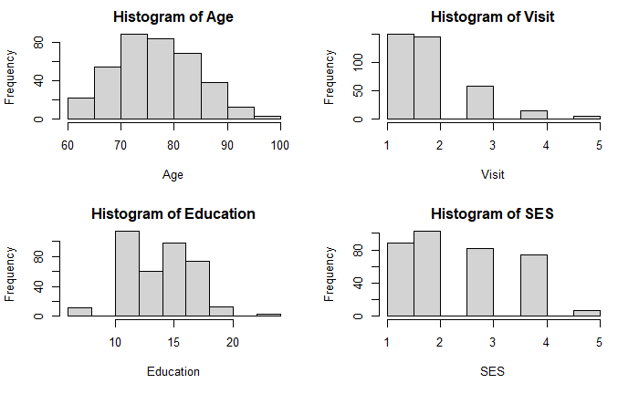

```r
hist(dem_data$EDUC, main = "Histogram of Education", xlab = "Education")

hist(dem_data$SES, main = "Histogram of SES", xlab = "SES")
```

```r
hist(dem_data$MR.Delay, main = "Histogram of MR.Delay", xlab = "MR.Delay")

hist(dem_data$CDR, main = "Histogram of CDR", xlab = "CDR")
```

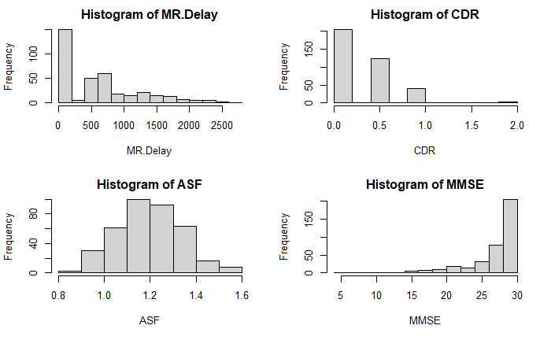

```r
hist(dem_data$ASF, main = "Histogram of ASF", xlab = "ASF")

hist(dem_data$MMSE, main = "Histogram of MMSE", xlab = "MMSE")
```

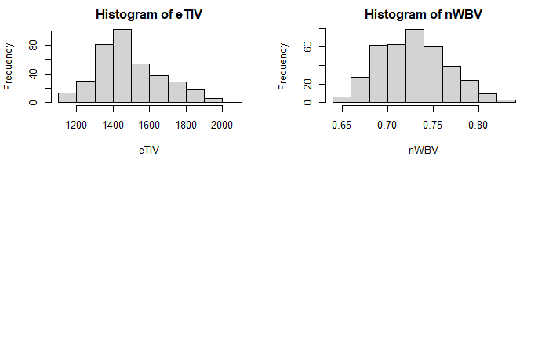

```r
hist(dem_data$eTIV, main = "Histogram of eTIV", xlab = "eTIV")

hist(dem_data$nWBV, main = "Histogram of nWBV", xlab = "nWBV")
```

```r
NA
NA
NA
NA
```

*Checking the columns if they are normally distributed or not using Shapiro wilk test.*

```r
# Initializing an empty vector to store non-normally distributed columns

non_normal_columns <- c()

# Looping through each column of the dataset

for (col in names(dem_data)) {

  # Checking if the column is numeric

  if (is.numeric(dem_data[[col]])) {

    # Performing Shapiro-Wilk test for normality

    shapiro_test <- shapiro.test(dem_data[[col]])

    # Check if the p-value is less than 0.05 (common significance level)

    if (shapiro_test$p.value < 0.05) {

      # If the p-value is less than 0.05 , column is not normally distributed

      non_normal_columns <- c(non_normal_columns, col)

      cat("Column", col, "is not normally distributed.\n")

    }

  }

}
```

```
Column Visit is not normally distributed.
Column MR.Delay is not normally distributed.
Column EDUC is not normally distributed.
Column SES is not normally distributed.
Column MMSE is not normally distributed.
Column CDR is not normally distributed.
Column eTIV is not normally distributed.
Column nWBV is not normally distributed.
Column ASF is not normally distributed.
```

**Inference** Based on the Shapiro Wilk test columns like Visit,MR.Delay, EDUC, SES, MMSE, CDR, eTIV, nWBV, ASF are not normally distributed.

**Detection of outliers for continuous features**

Identifying the outliers in the data is important as significantly impact statistical measures such as mean, standard deviation and correlation coefficients. By identifying the outliers , the statistical analysis can be more accurate and reliable. Moreover, the model performance is affected if the outliers are very high and affect overall accuracy of machine learning models. There are some models which are very sensitive to outliers and as a consequence reduces the model performance and make biased predictions.To check the outliers in the column, using z score z which is greater than the threshold and displaying the column names with Outliers count. Removing the outliers from the columns of dementia data and remove those outliers using z scores.

```r
# Creating a function outliers to calculate the outliers in column of dementia data
outlier <- function(column){
  # calculating mean and standard deviation of column
  mean_val <- mean(column)

  sd_val <- sd(column)
  # Calculating the z-score for column using mean and standard deviation

  z_val <-  abs((column - mean_val) /  sd_val)
  # print(z_val)

  # Finding outliers where z scores is greater than 3 threshold

  outliers <- which(z_val > 3)
  return(outliers)
}


# Creating an empty vector to store the row outliers
row_outliers <- c()
# Looping through each column of the data set
for (column in names(dem_data)) {

  # Checking the numeric columns in data
  if (is.numeric(dem_data[[column]])) {
    # Generating outliers list of column containing outliers
    outlier_list <- outlier(dem_data[[column]])

    # If length of outliers list is greater than 0
    if (length(outlier_list) > 0){
      # printing the coloumn consisting of outliers
      print(paste("The column", column, "has", length(outlier_list), "outliers present!"))
      print(paste("These outliers are at:", paste(outlier_list, collapse = ", ")))
      # Storing indices of rows with outliers
      row_outliers <- union(row_outliers, outlier_list)
    }
  }
}
```

```
[1] "The column Visit has 6 outliers present!"
[1] "These outliers are at: 33, 72, 102, 154, 161, 266"
[1] "The column MR.Delay has 3 outliers present!"
[1] "These outliers are at: 76, 161, 266"
[1] "The column CDR has 3 outliers present!"
[1] "These outliers are at: 185, 252, 331"
```

```r
# Remove rows with outliers
no_outliers_dem <- dem_data[-row_outliers, ]
#print(no_outliers_dem)
```

**Correlation analysis** Performing correlation analysis to identify highly correlated features and measure the strength and direction of relationship between the numeric variables which helps in quantification of changes in one variable associated with changes in another variable. The analysis shows positive, negative correlation between the variables. High correlations between the variable could lead to multi collinearity issues and hence the variables that are highly interrelated are removed to enhance the model performance and any redundancy.Correlation of 1 indicates a positive , high correlation, 0 indicates no correlation and -1 indicates the negative correlation.

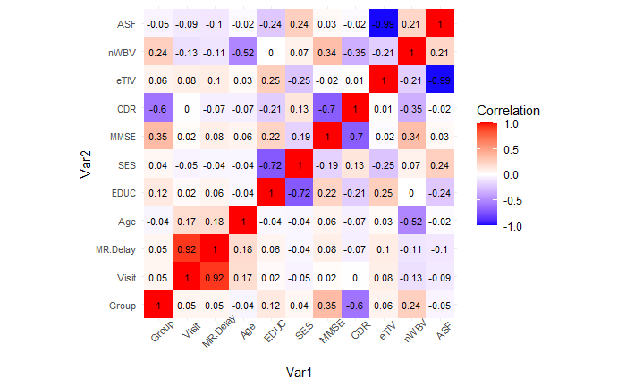

```r
# Storing  no_outliers dem in corr_dem_data
corr_dem_data <- no_outliers_dem

# converting group column into numeric and factoring the group column
corr_dem_data$Group <- as.numeric(factor(corr_dem_data$Group))


# Looking for numeric columns in dem_data
num_dem_data <- corr_dem_data[sapply(corr_dem_data, is.numeric)]

# Generating correlation matrix of numeric dem_data  using pairwise complete observations which calculate the pairs of observations that have non - missing values for the variables being correlated. In Case if any missing values are present in the different pair of observations, those pairs will still be used for correlation.

correlation_matrix <- cor(num_dem_data, use = "pairwise.complete.obs")

# Using melt to transform the correlation matrix to a long format or reshaping the data
melted_matrix <- melt(correlation_matrix)

# Creating a heatmap with correlation values
ggplot(data = melted_matrix, aes(Var1, Var2, fill = value)) +
  # Add tiles to the plot to represent in form of heatmap
  geom_tile() +
  # geom_text add text labels to each tile showing the rounded correlation values (to two decimal places) on the heatmap.
  # The labels will be displayed in black color and with a font size of 3.
  geom_text(aes(label = round(value, 2)), color = "black", size = 3) +
  # This set the color gradient for heatmap
  scale_fill_gradient2(low = "blue", mid = "white", high = "red",
                       midpoint = 0, limit = c(-1, 1), space = "Lab",
                       name = "Correlation") +
  # This sets up a minimal theme for the plot, removing unnecessary elements like gridlines.
  theme_minimal() +
  # customizing the appearance of axis text by rotating the x-axis labels by 45 degrees and adjusting their size. It also sets the size of the y-axis labels.
  theme(
    axis.text.x = element_text(angle = 45, vjust = 1, size = 8),
    axis.text.y = element_text(size = 8)
  ) +
  # Fixing the aspect ratio of plot
  coord_fixed()
```

```r
NA
NA
NA
```

*Data cleaning and shaping*

Identifying missing values in the columns of no outliers dem data and displaying the names of column consisting of missing values in the data.

```r
# Check for missing values in each column

missing_values <- colSums(is.na(no_outliers_dem))

# Display columns with missing values

names_with_missing <- names(missing_values[missing_values > 0])

print(names_with_missing)
```

```
[1] "SES"  "MMSE"
```

Since SES and MMSE columns consist of missing values. Cleaning the data further to impute the missing values.

Imputing missing values in a column of SES and MMSE with median since imputing the values with median is not influenced by extreme values or outliers in the data. It gives a good measure of central tendency, especially when the distribution of data is skewed or not normal.

```r
# Replace missing values in 'SES' column with median

median_ses <- median(no_outliers_dem$SES[!is.na(no_outliers_dem$SES)])

no_outliers_dem$SES[is.na(no_outliers_dem$SES)] <- median_ses



# Replace missing values in 'MMSE' column with median

median_mmse <- median(no_outliers_dem$MMSE[!is.na(no_outliers_dem$MMSE)])

no_outliers_dem$MMSE[is.na(no_outliers_dem$MMSE)] <- median_mmse


head(no_outliers_dem,4)
```

|  | Subject.ID | MRI.ID | Group | Visit | MR.Delay | M.F | Hand | Age | EDUC | SES | MMSE | CDR | eTIV | nWBV | ASF |
| --- | --- | --- | --- | --- | --- | --- | --- | --- | --- | --- | --- | --- | --- | --- | --- |
| 1 | OAS2_0001 | OAS2_0001_MR1 | Nondemented | 1 | 0 | M | R | 87 | 14 | 2 | 27 | 0.0 | 1987 | 0.696 | 0.883 |
| 2 | OAS2_0001 | OAS2_0001_MR2 | Nondemented | 2 | 457 | M | R | 88 | 14 | 2 | 30 | 0.0 | 2004 | 0.681 | 0.876 |
| 3 | OAS2_0002 | OAS2_0002_MR1 | Demented | 1 | 0 | M | R | 75 | 12 | 2 | 23 | 0.5 | 1678 | 0.736 | 1.046 |
| 4 | OAS2_0002 | OAS2_0002_MR2 | Demented | 2 | 560 | M | R | 76 | 12 | 2 | 28 | 0.5 | 1738 | 0.713 | 1.010 |

```r
#is.na(dem_data)
```

**Evaluation of distribution**

Plotting histogram after removing the outliers and checking the spread of the data

```r
# Histograms for Age, EDUC, eTIV, nWBV,Visit,SES,MR.Delay,CDR,ASF,MMSE

par(mfrow = c(2, 2)) # Set up a grid of 2x2 plots

hist(no_outliers_dem$Age, main = "Histogram of Age", xlab = "Age")

hist(no_outliers_dem$Visit , main = "Histogram of Visit", xlab = "Visit")
```

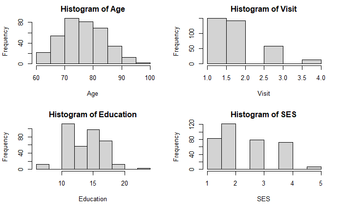

```r
hist(no_outliers_dem$EDUC, main = "Histogram of Education", xlab = "Education")

hist(no_outliers_dem$SES, main = "Histogram of SES", xlab = "SES")
```

```r
hist(no_outliers_dem$MR.Delay, main = "Histogram of MR.Delay", xlab = "MR.Delay")

hist(no_outliers_dem$CDR, main = "Histogram of CDR", xlab = "CDR")
```

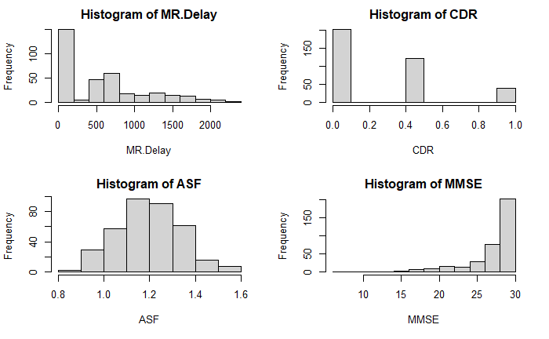

```r
hist(no_outliers_dem$ASF, main = "Histogram of ASF", xlab = "ASF")

hist(no_outliers_dem$MMSE, main = "Histogram of MMSE", xlab = "MMSE")
```

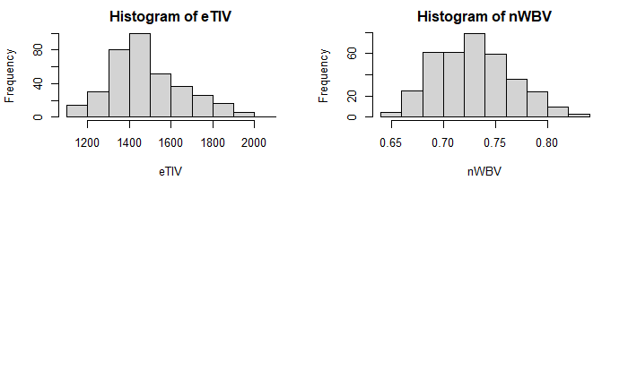

```r
hist(no_outliers_dem$eTIV, main = "Histogram of eTIV", xlab = "eTIV")

hist(no_outliers_dem$nWBV, main = "Histogram of nWBV", xlab = "nWBV")
```

```r
NA
NA
NA
NA
NA
```

*Inference* After looking at the plots, there are some features in the data which are still not normally distributed

Normalizing through Z score. Scaling the data to to make th data normally distributed.

```r
# Taking numerical columns from the no outliers dementia data
numeric_cols <- names(no_outliers_dem)[sapply(no_outliers_dem, is.numeric)]


# Performing z score normalization
scaled_data <- as.data.frame(scale(no_outliers_dem[numeric_cols]))

# Displaying the scaled data
head(scaled_data)
```

|  | Visit | MR.Delay | Age | EDUC | SES | MMSE | CDR | eTIV | nWBV | ASF |
| --- | --- | --- | --- | --- | --- | --- | --- | --- | --- | --- |
| 1 | -0.9858305 | -0.944113610 | 1.3363066 | -0.2007407 | -0.4015714 | -0.1325656 | -0.8087227 | 2.848352 | -0.9172790 | -2.276120 |
| 2 | 0.2110139 | -0.176342408 | 1.4681933 | -0.2007407 | -0.4015714 | 0.7423673 | -0.8087227 | 2.944895 | -1.3234418 | -2.326760 |
| 3 | -0.9858305 | -0.944113610 | -0.2463338 | -0.8947300 | -0.4015714 | -1.2991427 | 0.6518063 | 1.093533 | 0.1658218 | -1.096936 |
| 4 | 0.2110139 | -0.003299883 | -0.1144471 | -0.8947300 | -0.4015714 | 0.1590787 | 0.6518063 | 1.434274 | -0.4569611 | -1.357369 |
| 5 | 1.4078583 | 2.239532841 | 0.4130997 | -0.8947300 | -0.4015714 | -1.5907870 | 0.6518063 | 1.207114 | -0.7818914 | -1.183747 |
| 6 | -0.9858305 | -0.944113610 | 1.4681933 | 1.1872379 | 0.5038349 | 0.1590787 | -0.8087227 | -1.535856 | -0.5381937 | 1.782297 |

```r
NA
NA
NA
NA
NA
```

Applying Shapiro wilk test to check if the columns are normally distributer after applying scaling through z score.

```r
# Initializing an empty vector to store non-normally distributed columns

no_normal_cols <- c()

# Looping through each column of the dataset

for (col in names(scaled_data)) {

  # Checking if the column is numeric

  if (is.numeric(scaled_data[[col]])) {

    # Performing Shapiro-Wilk test for normality

    shapiro_test <- shapiro.test(scaled_data[[col]])

    # Check if the p-value is less than 0.05 (common significance level)

    if (shapiro_test$p.value < 0.05) {

      # If the p-value is less than 0.05 , column is not normally distributed

      no_normal_cols <- c(no_normal_cols,col)

      cat("Column", col, "is not normally distributed.\n")

    }

  }

}
```

```
Column Visit is not normally distributed.
Column MR.Delay is not normally distributed.
Column EDUC is not normally distributed.
Column SES is not normally distributed.
Column MMSE is not normally distributed.
Column CDR is not normally distributed.
Column eTIV is not normally distributed.
Column nWBV is not normally distributed.
Column ASF is not normally distributed.
```

*Inference* Howeever, even after apply Shapiro-Wilk test the coloums like Visit, MR.Delay, EDUcation, SES, MMSE, CDR, eTIV, nWBV and ASF are not normally distributed

Since from the histogram , the plots are skewed, performing log transformation on the data to transform the data and checking if the data is normally distributed

```r
# Taking numerical columns from no_outliers_dem
num_Col <- names(no_outliers_dem)[sapply(no_outliers_dem, is.numeric)]

# Performing log transformation on numeric columns of dementia data
log_transformed_data <- as.data.frame(lapply(no_outliers_dem[num_Col], log))

print(log_transformed_data)
```

[output not shown]

[output cut: 353 more lines]

```r
NA
NA
NA
```

Applied shapiro wilk test on log transformed data

```r
# Taking column names from log transformed data
cols <- colnames(log_transformed_data)
#  randomly sampling rows with replacement from the log_transformed_data dataframe and creating a subset named sample_subset. sample() is used to generate random row indices based on the number of rows in the dataset (nrow(log_transformed_data)) with replacement.
sample_subset <- log_transformed_data[sample(nrow(log_transformed_data), replace = TRUE), ]

# Retrieving column names from sample subset
sample_cols <- colnames(sample_subset)

# for column in sample columns
for (col in sample_cols) {
  # performing shapiro test on each column in sample subset
  shap <- shapiro.test(sample_subset[, col])
  # retrieving the p value from Shapiro wilk test stored in shap
  val <- shap$p.value
  # Checks if the p-value is not NA (i.e., the test was valid) and if the p-value is greater than 0.05 (indicating the data follows a normal distribution). If these conditions are met, it prints a message indicating that the specific column follows a normal distribution.
  if (!is.na(val) && val > 0.05) {
    print(paste0("The column ", col ," follows a normal distribution"))
  }
}
```

```
[1] "The column Age follows a normal distribution"
```

**Inference** After log transformation data , the data is still not getting transformed.Trying square root transformation and again applying shapiro wilk test.

Applying Square root transformation on the data

```r
# Taking numerical columns from 'no_outliers_dem'
num_Col <- names(no_outliers_dem)[sapply(no_outliers_dem, is.numeric)]

# Square root transformation of numeric columns
sqrt_transformed_data <- as.data.frame(lapply(no_outliers_dem[num_Col], sqrt))

#print(sqrt_transformed_data)
```

```r
# Taking column names from square rooot transformed data
cols <- colnames(sqrt_transformed_data)
#  randomly sampling rows with replacement from the sqrt_transformed_data dataframe and creating a subset named sample_subset. sample() is used to generate random row indices based on the number of rows in the dataset (nrow(sqrt_transformed_data)) with replacement.
sample_subset <- sqrt_transformed_data[sample(nrow(sqrt_transformed_data), replace = TRUE), ]

# Retrieving column names from sample subset
sample_cols <- colnames(sample_subset)

# for column in sample columns
for (col in sample_cols) {
  # performing shapiro test on each column in sample subset
  shap <- shapiro.test(sample_subset[, col])
  # retrieving the p value from Shapiro wilk test stored in shap
  val <- shap$p.value
  # Checks if the p-value is not NA (i.e., the test was valid) and if the p-value is greater than 0.05 (indicating the data follows a normal distribution). If these conditions are met, it prints a message indicating that the specific column follows a normal distribution.
  if (!is.na(val) && val > 0.05) {
    print(paste0("The column ", col ," follows a normal distribution"))
  }
}
```

```
[1] "The column Age follows a normal distribution"
```

To understand the feature importance, looking at different plots to check which features are associated with predicting dementia.

*Plotting a violin plot to check Distribution of Age and gender by CDR rate*

Each violin represent the distribution of Age across different categories of CDR rate(Clinical dementia rating).The width of the violin at different points indicates the density of the data, so wider sections represent a higher density of cases (more people of that age). To differentiate between the gender male and female used different colors.At x axis is the CDR rate with different CDR rates 0,0.5 and 1 to categorize severity of symptoms. Higher scores indicate severe cognitive impairment.

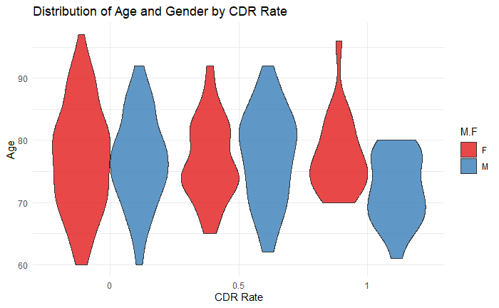

```r
# Loading library ggplot2
library(ggplot2)


# Filtering CDR values from dataset to keep it as 0,0.5 and 1
dem_data_fill <- no_outliers_dem[no_outliers_dem$CDR %in% c(0, 0.5, 1), ]

# Generating a violin plot through ggplot to visualize the distribution of Age and Gender by CDR rate
ggplot(dem_data_fill, aes(x = factor(CDR), y = Age, fill = M.F)) +
  geom_violin(scale = "width", alpha = 0.8) +
  # setting labels x and y , setting up the title
  labs(x = "CDR Rate", y = "Age", title = "Distribution of Age and Gender by CDR Rate") +
    scale_x_discrete(labels = c("0" = "0", "0.5" = "0.5", "1" = "1")) +
  # setting colors for female and male gender
 scale_fill_brewer(palette = "Set1") +
  theme_minimal()
```

```r
NA
NA
NA
NA
NA
```

*Plotting a strip plot to look at the distribution of MMSE with Group*

The strip plot is a form of scatter plot designed to visualize the distribution of a continuous variable within categories. On the x axis, there are 3 categories demented, non demented and Converted. Each represents the individual classified on the basis of cognitive stus. Each dot on the plot represents an individual observation, with the position along the y-axis indicating the MMSE value for that observation. The points are ‘striped’ or ‘jittered’ horizontally to avoid overlap so that the density of points can be visually assessed.The colors are used to differentiate the groups: ‘Converted’ is in pink, ‘Demented’ in green, and ‘Nondemented’ in blue.

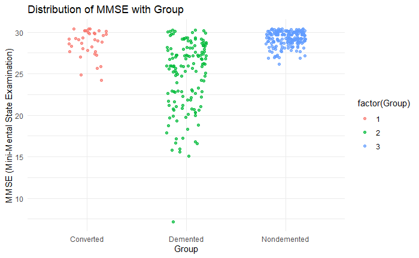

```r
# Storing no_outliers_dem into a new variable new_dem_data
new_dem_data <- no_outliers_dem
# Convert Group column to a numeric factor
new_dem_data$Group <- as.numeric(factor(new_dem_data$Group))

# Load necessary libraries
library(ggplot2)

# Creating a strip plot to visualize the distribution of MMSE with Group
ggplot(new_dem_data, aes(x = factor(Group), y = MMSE, color = factor(Group))) +
  geom_jitter(width = 0.2, alpha = 0.7) +
  labs(x = "Group", y = "MMSE (Mini-Mental State Examination)",
       title = "Distribution of MMSE with Group") +
  scale_x_discrete(labels = c("1" = "Converted", "2" = "Demented", "3" = "Nondemented")) +
  theme_minimal()
```

```r
NA
NA
NA
```

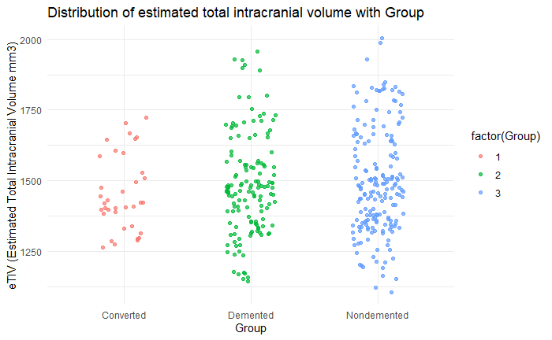

```r
# Loading Library ggplot2
library(ggplot2)


# Creating a strip plot to visualize the distribution of eTIV with Group
ggplot(new_dem_data, aes(x = factor(Group), y = eTIV, color = factor(Group))) +
  # Plotting a strip plot through  geom_jitter
  geom_jitter(width = 0.2, alpha = 0.7) +
  labs(x = "Group", y = "eTIV (Estimated Total Intracranial Volume mm3)",
       title = "Distribution of estimated total intracranial volume with Group ") +
  # Setting specific x-axis labels
  scale_x_discrete(labels = c("1" = "Converted", "2" = "Demented", "3" = "Nondemented")) +
  theme_minimal()
```

```r
NA
NA
NA
NA
NA
NA
```

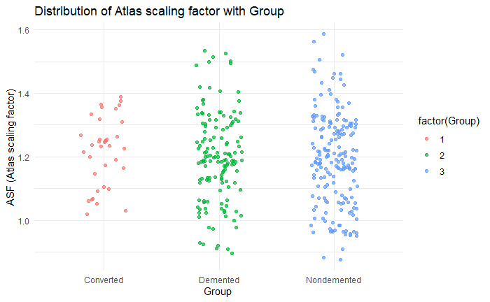

```r
# Loading Library ggplot2
library(ggplot2)


# Creating a strip plot to visualize the distribution of ASF with Group
ggplot(new_dem_data, aes(x = factor(Group), y = ASF, color = factor(Group))) +
   # Plotting a strip plot through  geom_jitter
  geom_jitter(width = 0.2, alpha = 0.7) +
  labs(x = "Group ", y = "ASF (Atlas scaling factor)",
       title = "Distribution of Atlas scaling factor with Group") +
  scale_x_discrete(labels = c("1" = "Converted", "2" = "Demented", "3" = "Nondemented")) +  # Set specific x-axis labels
  theme_minimal()
```

```r
NA
NA
NA
```

# Identification of PCA(Principal component analysis)

Principal Component Analysis (PCA) provides information about the importance of each principal component (PC) in the dataset.The standard deviation component indicates the spread of the data. Higher the standard deviations higher the spread of the data. Proportion of Variance tells the variation captured by each principal component.Cumulative proportion of variance explains the total variance in dataset captured by each component in sequence. The handedness is right which make it insignificant to select the feature, to avoid multi collinearity removing ASF feature, not selecting subject ids and mri id’s for the data. Selecting features like “Group”, “Visit”, “MR.Delay”, “M.F”, “Age”, “EDUC”,“SES”,“MMSE”, “CDR”,“eTIV”, “nWBV and looking at the principal component analysis.

```r
# storing no_outliers_dem into new variable pca_dem_data
pca_dem_data <- no_outliers_dem

# converting group column into numeric and factoring the group column
#ca_dem_data$Group <- factor(pca_dem_data$Group, levels = c("Nondemented", "Demented", "Converted"), labels = c(0,1,2))

pca_dem_data$Group <- as.numeric(factor(pca_dem_data$Group))

pca_dem_data$M.F <- (as.numeric(factor(pca_dem_data$M.F)))



# Select specific columns from the data
selecting_pca_dem_data <- pca_dem_data[,c("Group", "Visit", "MR.Delay", "M.F", "Age", "EDUC","SES","MMSE", "CDR","eTIV", "nWBV")]


# Taking numeric columns from the data.Applying is.numeric() function to each column of pca_dem_data and returns a logical vector indicating whether each column is numeric or not.
dem_data_numeric <- selecting_pca_dem_data[, sapply(selecting_pca_dem_data, is.numeric)]

# Perform PCA using the prcomp() function on the subset dem_data_numeric.scale. = TRUE standardizes the variables (centers and scales) before PCA by subtracting means and dividing by standard deviations.
pca_analysis <- prcomp(dem_data_numeric, scale. = TRUE)

#Generating summary of pca results
summary(pca_analysis)
```

```
Importance of components:
                          PC1    PC2    PC3    PC4    PC5     PC6     PC7    PC8    PC9    PC10    PC11
Standard deviation     1.5912 1.4983 1.3517 1.1252 1.0855 0.80608 0.62812 0.5599 0.5307 0.48591 0.27656
Proportion of Variance 0.2302 0.2041 0.1661 0.1151 0.1071 0.05907 0.03587 0.0285 0.0256 0.02146 0.00695
Cumulative Proportion  0.2302 0.4342 0.6003 0.7154 0.8225 0.88161 0.91748 0.9460 0.9716 0.99305 1.00000
```

**Inference** Based on the summary of PCA analysis, we can identify the components which are important to keep.PC1 explains 23.02% of the variance. PC2 explains an additional 20.41% for a cumulative total of 43.42%.PC3 adds 16%If the cumulative proportion reaches a satisfactory threshold (e.g., 70-90%) with fewer components , those features can be considered. PC1 to PC5 explains large proportion of total variance. However, other components from PC6 to PC11 might contribute to dataset information.

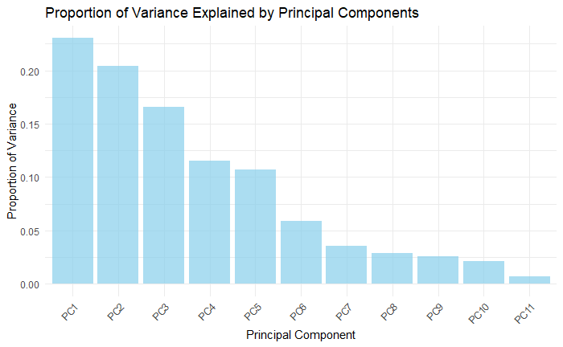

```r
# Sample data of proportion of variance explained by each principal component
variance_explained <- c(0.2302, 0.2041, 0.1661, 0.1151, 0.1071, 0.05907, 0.03587, 0.0285, 0.0256, 0.02146, 0.00695)

# Creating a data frame for plotting
df <- data.frame(
  PC = paste0("PC", 1:length(variance_explained)),
  VarianceExplained = variance_explained
)


# Reordering the levels of the PC factor in the data frame
df$PC <- factor(df$PC, levels = paste0("PC", 1:length(variance_explained)))

# Plotting a bar chart
library(ggplot2)

ggplot(df, aes(x = PC, y = VarianceExplained)) +
  geom_bar(stat = "identity", fill = "skyblue", alpha = 0.7) +
  labs(title = "Proportion of Variance Explained by Principal Components",
       x = "Principal Component", y = "Proportion of Variance") +
  theme_minimal() +
  theme(axis.text.x = element_text(angle = 45, hjust = 1))  # Rotating x-axis labels for better readability
```

```r
NA
NA
NA
```

**Inference** Plotted proportion of variance bar plot of prinicipal components which illustrates the amount of variance each principal component captures from the total variance in the dataset. In PCA, principal components are created to summarize the variation present in the original variables. These components are ordered by the amount of variance. The proportion of variance plot shows how much variance in the data is explained by each principal component. It helps in understanding the relative importance of each component in retaining information from the original dataset.

```r
# Performing pca on the dem_data numeric data
pca_analysis <- prcomp(dem_data_numeric, scale. = TRUE)

#  standard deviations of each principal component is calculated by the proportion of variance explained by each principal component. It squares the standard deviations, divides each squared value by the sum of all squared standard deviations, and returns the result as a vector.
pca_analysis$sdev^2 /sum(pca_analysis$sdev^2)
```

```
 [1] 0.230167148 0.204072721 0.166088067 0.115102942 0.107109402 0.059069066 0.035867310 0.028502842 0.025603185 0.021464343 0.006952973
```

```r
# Extract eigenvalues, loadings (eigenvectors), and principal components
# reverse the signs as eigenvectors in R point in the negative direction by default
pca_analysis$rotation <- -1 * pca_analysis$rotation


#
pca_analysis$rotation
```

```
                 PC1         PC2          PC3         PC4        PC5         PC6          PC7           PC8         PC9        PC10
Group     0.42006752  0.03965576 -0.069734444 -0.14614949  0.3713589  0.68147210 -0.110548353  0.0214400158  0.24754937 -0.33752398
Visit    -0.01034289  0.47105968 -0.440839048 -0.20547780 -0.2105047  0.03009051 -0.014920374  0.0095016344  0.10345388 -0.02067708
MR.Delay  0.02405442  0.47712806 -0.439591011 -0.19614520 -0.1928212 -0.03748546 -0.005141191 -0.0009871817 -0.10372398  0.05365700
M.F      -0.24899235  0.23510106  0.303332896 -0.41474203  0.3265350 -0.26070655 -0.571471041 -0.2215529345  0.25745740  0.03598723
Age      -0.09089874  0.26018181 -0.186901797  0.61211204  0.3783727 -0.12317863  0.110548472 -0.5587054999  0.06398716 -0.16620265
EDUC      0.21480235  0.32158666  0.426793322  0.13691076 -0.3083788  0.21168522 -0.298122766 -0.2241066212 -0.59177557 -0.12138087
SES      -0.13499685 -0.32486947 -0.416051418 -0.25445797  0.3922451 -0.02624383 -0.153768258 -0.0764423140 -0.66141883 -0.09143477
MMSE      0.49597474  0.08759736 -0.001958655  0.08817893  0.1259972 -0.59772894 -0.095712798  0.3862952338 -0.03529392 -0.45312020
CDR      -0.54378963 -0.06640238  0.038520135 -0.05527384 -0.2700558  0.07107950  0.051707366  0.0339227921  0.05932877 -0.77779667
eTIV     -0.08187196  0.35627814  0.351851102 -0.31897597  0.3499753 -0.01875099  0.683884242  0.0727934625 -0.20718180 -0.02682341
nWBV      0.37394197 -0.27917217 -0.008746380 -0.39393446 -0.2656454 -0.20484419  0.238066774 -0.6530472227  0.10731363 -0.14054838
                  PC11
Group    -0.0745166633
Visit     0.6962577147
MR.Delay -0.6984315908
M.F      -0.0295172120
Age       0.0001981815
EDUC      0.0748609351
SES       0.0923025915
MMSE      0.0212767972
CDR      -0.0710645650
eTIV      0.0366518274
nWBV     -0.0049305746
```

Factoring categorical variables

```r
# Factoring the group  categorical variable nondemented , demented and converted
no_outliers_dem$Group <- as.factor(no_outliers_dem$Group)
# Factoring Gender M.F categorical variables
no_outliers_dem$M.F <- as.factor(no_outliers_dem$M.F)


# Storing no_outliers_dem in factored data
factored_data <- no_outliers_dem
```

```r
# Select specific columns from the data

select_data <- factored_data[, c("Group","Visit","MR.Delay","M.F","Age","EDUC","SES","MMSE","CDR","eTIV","nWBV")]

#print(select_data)
```